# Understanding Factors That Influence Insurance Charges

Sean Schilk

9/20/2025

```r
# Read in dataset
library(readr)
insurance <- read_csv("https://sschilk.github.io/Topics-In-Advanced-Statistics/datasets/insurance.csv")
```

# 1 Data Description

I’m using a data set provided by Mosap Abdel-Ghany on Kaggle called “Medical Insurance Cost Dataset”. The data was collected from a collection of 1338 individuals from medical insurance records.

The primary practical question is to see how the variables in the data set or derived variables from the data set affect insurance cost.

The variables names in the data set and their variable type are the following:

age (numeric) sex (character) bmi (numeric) - a measure of body fat based on height and weigh children (numeric) - Number of children covered by health insurance smoker (character) - Smoking status of the beneficiary region (character)- Residential region in the US charges (numeric) - Medical insurance cost billed to the beneficiary

# 2 Exploratory Data Analysis

```r
head(insurance)
```

```
# A tibble: 6 × 7
    age sex      bmi children smoker region    charges
  <dbl> <chr>  <dbl>    <dbl> <chr>  <chr>       <dbl>
1    19 female  27.9        0 yes    southwest  16885.
2    18 male    33.8        1 no     southeast   1726.
3    28 male    33          3 no     southeast   4449.
4    33 male    22.7        0 no     northwest  21984.
5    32 male    28.9        0 no     northwest   3867.
6    31 female  25.7        0 no     southeast   3757.
```

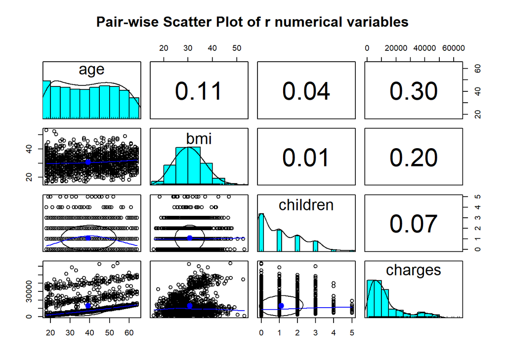

```r
final.data <- insurance
library(psych)
pairs.panels(insurance[, -c(2,5,6)], pch=21,
             main="Pair-wise Scatter Plot of r numerical variables") #to show color grouping
```

We start the search process for the final model. We start with a linear model that includes all predictor variables.

```r
library(knitr)
full.model = lm(charges ~ ., data = final.data)
kable(summary(full.model)$coef, caption ="Statistics of Regression Coefficients")
```

Statistics of Regression Coefficients

|  | Estimate | Std. Error | t value | Pr(>\|t\|) |
| --- | --- | --- | --- | --- |
| (Intercept) | -11938.5386 | 987.81918 | -12.0857530 | 0.0000000 |
| age | 256.8564 | 11.89885 | 21.5866552 | 0.0000000 |
| sexmale | -131.3144 | 332.94544 | -0.3944020 | 0.6933475 |
| bmi | 339.1935 | 28.59947 | 11.8601306 | 0.0000000 |
| children | 475.5005 | 137.80409 | 3.4505546 | 0.0005770 |
| smokeryes | 23848.5345 | 413.15335 | 57.7232020 | 0.0000000 |
| regionnorthwest | -352.9639 | 476.27579 | -0.7410914 | 0.4587689 |
| regionsoutheast | -1035.0220 | 478.69221 | -2.1621870 | 0.0307817 |
| regionsouthwest | -960.0510 | 477.93302 | -2.0087563 | 0.0447649 |

Next, we conduct residual diagnostic analysis to check the validity of the model before making an inference about the model.

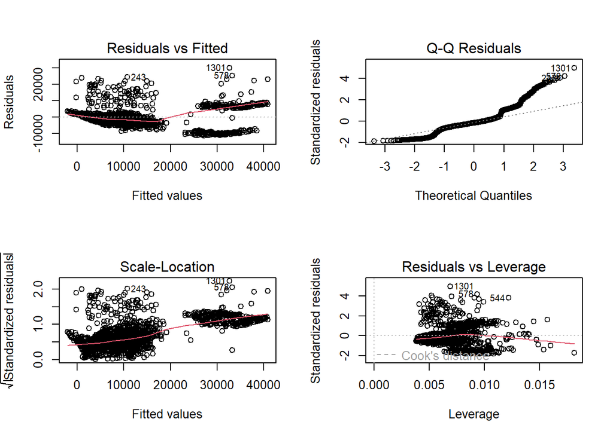

```r
par(mfrow=c(2,2))
plot(full.model)
```

We can see from the residual plots that there are some minor violations: The residuals vs fitted plot is not showing random scatter around y=0, so the assumption of constant variance is violated. Along with our assumption of normality, our QQ plot shows a violation here as well. We also can see the presence of outliers.

Let’s also check for multicollinearity.

```r
library(car)
vif(full.model)
```

```
             GVIF Df GVIF^(1/(2*Df))
age      1.016822  1        1.008376
sex      1.008900  1        1.004440
bmi      1.106630  1        1.051965
children 1.004011  1        1.002003
smoker   1.012074  1        1.006019
region   1.098893  3        1.015841
```

The VIF indices show that there is no significant issues on multicollinearity. We first perform Box-Cox transformation to correct the non-constant variance and correct the non-normality of the QQ plot. Since non-constant variance, we perform the Box-Cox procedure to search for a transformation of the response variable

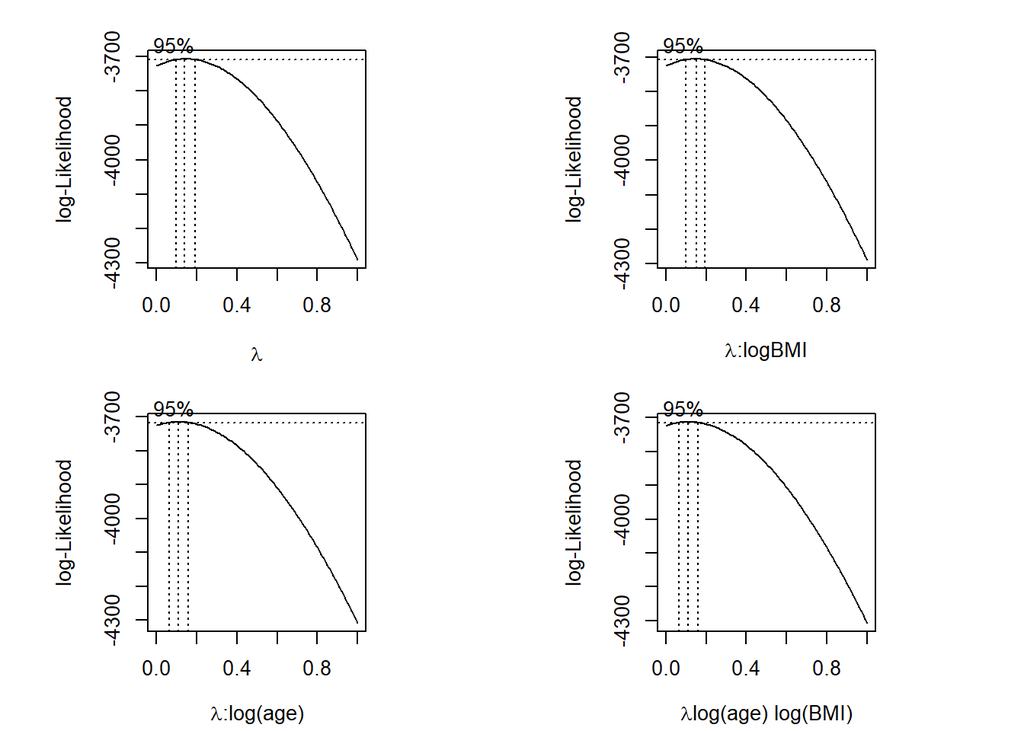

```r
library(MASS)
par(pty = "s", mfrow = c(2, 2), oma=c(.1,.1,.1,.1), mar=c(4, 0, 2, 0))
##
boxcox(charges ~ age + sex + bmi + children + smoker + region,
       data=final.data,
       lambda = seq(0, 1, length = 10),
       xlab=expression(paste(lambda)))
##
boxcox(charges ~ age + sex + log(bmi) + children + smoker + region,
       data=final.data,
       lambda = seq(0, 1, length = 10),
       xlab=expression(paste(lambda, ":logBMI")))
##
boxcox(charges ~ log(age) + sex + bmi + children + smoker + region,
       data=final.data,
       lambda = seq(0, 1, length = 10),
       xlab=expression(paste(lambda,":log(age)")))
##
boxcox(charges ~ log(age) + sex + log(bmi) + children + smoker + region,
       data=final.data,
       lambda = seq(0, 1, length = 10),
       xlab=expression(paste(lambda,"log(age) log(BMI)")))
```

The best lambda is the one at the peak of the curve. As lambda did not change as a result of log(BMI), the main issue is in the response variable, not bmi. However, log transformed age impacts the coefficient of the power transformation: lambda. Therefore We perform Box-Cox transformation with log-transformed age in the following.

```r
lambda = .11
log.age.m = lm((charges)^lambda ~ log(age) + sex + bmi + children + smoker + region,
       data=final.data)
kable(summary(log.age.m)$coef, caption = "log-transformed model")
```

log-transformed model

|  | Estimate | Std. Error | t value | Pr(>\|t\|) |
| --- | --- | --- | --- | --- |
| (Intercept) | 1.2273386 | 0.0372034 | 32.989972 | 0.0000000 |
| log(age) | 0.3553772 | 0.0093268 | 38.102662 | 0.0000000 |
| sexmale | -0.0196954 | 0.0072387 | -2.720852 | 0.0065964 |
| bmi | 0.0046117 | 0.0006213 | 7.423131 | 0.0000000 |
| children | 0.0222275 | 0.0030055 | 7.395525 | 0.0000000 |
| smokeryes | 0.4812078 | 0.0089820 | 53.574520 | 0.0000000 |
| regionnorthwest | -0.0180103 | 0.0103548 | -1.739332 | 0.0822080 |
| regionsoutheast | -0.0445159 | 0.0104070 | -4.277513 | 0.0000203 |
| regionsouthwest | -0.0373495 | 0.0103907 | -3.594513 | 0.0003369 |

Residual plots are given below.

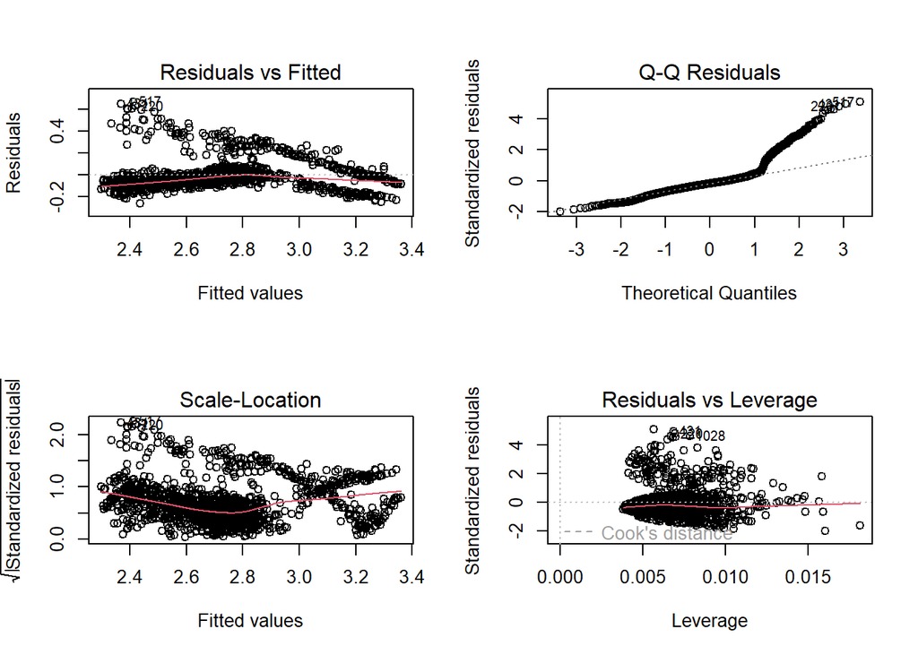

```r
par(mfrow = c(2,2))
plot(log.age.m)
```

There are some improvements in the above residual diagnostic plots. Though non-constant variance and the violation of normality are both still issues.

```r
log.charges = lm(log(charges) ~ age + sex + bmi + children + smoker + region,
       data=final.data)
kable(summary(log.charges)$coef, caption = "log-transformed model")
```

log-transformed model

|  | Estimate | Std. Error | t value | Pr(>\|t\|) |
| --- | --- | --- | --- | --- |
| (Intercept) | 7.0305581 | 0.0723960 | 97.112464 | 0.0000000 |
| age | 0.0345816 | 0.0008721 | 39.655485 | 0.0000000 |
| sexmale | -0.0754164 | 0.0244012 | -3.090691 | 0.0020384 |
| bmi | 0.0133748 | 0.0020960 | 6.381058 | 0.0000000 |
| children | 0.1018568 | 0.0100995 | 10.085345 | 0.0000000 |
| smokeryes | 1.5543228 | 0.0302795 | 51.332517 | 0.0000000 |
| regionnorthwest | -0.0637876 | 0.0349057 | -1.827427 | 0.0678597 |
| regionsoutheast | -0.1571967 | 0.0350828 | -4.480741 | 0.0000081 |
| regionsouthwest | -0.1289522 | 0.0350271 | -3.681497 | 0.0002412 |

Residual plots are given below.

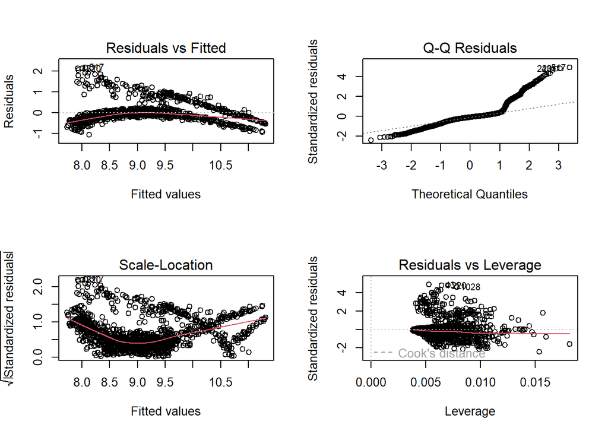

```r
par(mfrow = c(2,2))
plot(log.charges)
```

Similar to the previous model, where non constant variance is still an issue. The QQplots of all 3 models are similar, meaning that the assumption of normal residuals for all 3 models is not satisfied.

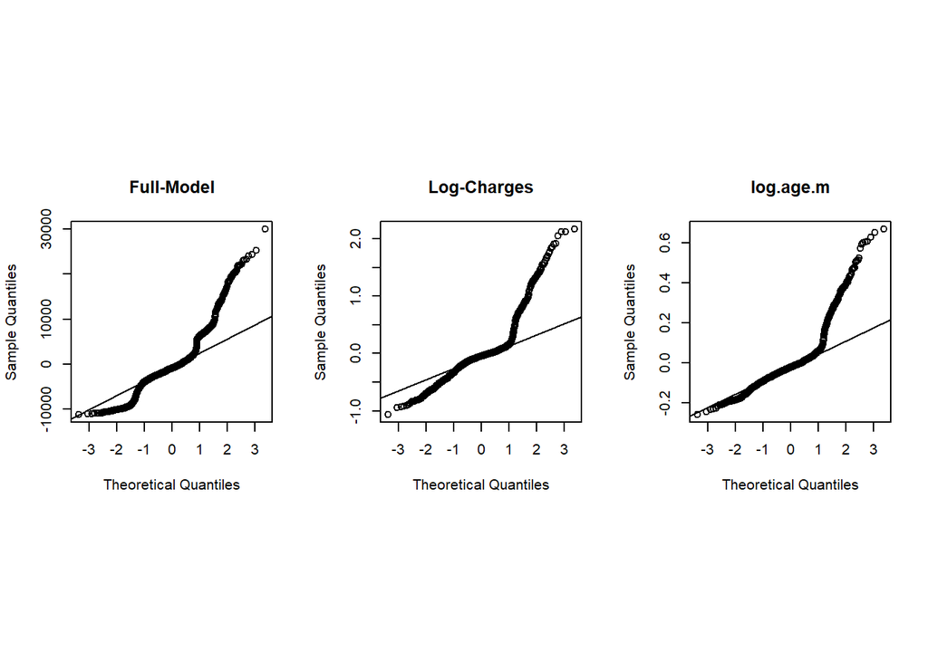

```r
#define plotting area
par(pty = "s", mfrow = c(1, 3))
#Q-Q plot for original model
qqnorm(full.model$residuals, main = "Full-Model")
qqline(full.model$residuals)
#Q-Q plot for Box-Cox transformed model
qqnorm(log.charges$residuals, main = "Log-Charges")
qqline(log.charges$residuals)
#display both Q-Q plots
qqnorm(log.age.m$residuals, main = "log.age.m")
qqline(log.age.m$residuals)
```

Next, we extract several other goodness-of-fit from each of the three candidate models and summarize them in the following table.

```r
select=function(m){ # m is an object: model
 e = m$resid                           # residuals
 n0 = length(e)                        # sample size
 SSE=(m$df)*(summary(m)$sigma)^2       # sum of squared error
 R.sq=summary(m)$r.squared             # Coefficient of determination: R square!
 R.adj=summary(m)$adj.r                # Adjusted R square
 MSE=(summary(m)$sigma)^2              # square error
 Cp=(SSE/MSE)-(n0-2*(n0-m$df))         # Mellow's p
 AIC=n0*log(SSE)-n0*log(n0)+2*(n0-m$df)          # Akaike information criterion
 SBC=n0*log(SSE)-n0*log(n0)+(log(n0))*(n0-m$df)  # Schwarz Bayesian Information criterion
 X=model.matrix(m)                     # design matrix of the model
 H=X%*%solve(t(X)%*%X)%*%t(X)          # hat matrix
 d=e/(1-diag(H))
 PRESS=t(d)%*%d   # predicted residual error sum of squares (PRESS)- a cross-validation measure
 tbl = as.data.frame(cbind(SSE=SSE, R.sq=R.sq, R.adj = R.adj, Cp = Cp, AIC = AIC, SBC = SBC, PRD = PRESS))
 names(tbl)=c("SSE", "R.sq", "R.adj", "Cp", "AIC", "SBC", "PRESS")
 tbl
 }
```

```r
library(dplyr)
output.sum = rbind(select(full.model), select(log.age.m), select(log.charges))
row.names(output.sum) = c("full.model", "log.age.m", "log.charges")
kable(output.sum, caption = "Goodness-of-fit Measures of Candidate Models")
```

Goodness-of-fit Measures of Candidate Models

|  | SSE | R.sq | R.adj | Cp | AIC | SBC | PRESS |
| --- | --- | --- | --- | --- | --- | --- | --- |
| full.model | 4.883953e+10 | 0.7509130 | 0.7494136 | 9 | 23316.426 | 23363.217 | 4.958132e+10 |
| log.age.m | 2.308519e+01 | 0.7725224 | 0.7711531 | 9 | -5413.932 | -5367.142 | 2.341409e+01 |
| log.charges | 2.623290e+02 | 0.7679478 | 0.7665509 | 9 | -2162.046 | -2115.256 | 2.660277e+02 |

The inferential statistics of the final working model are summarized in the following table.

```r
kable(summary(log.age.m)$coef, caption = "Inferential Statistics of Model")
```

Inferential Statistics of Model

|  | Estimate | Std. Error | t value | Pr(>\|t\|) |
| --- | --- | --- | --- | --- |
| (Intercept) | 1.2273386 | 0.0372034 | 32.989972 | 0.0000000 |
| log(age) | 0.3553772 | 0.0093268 | 38.102662 | 0.0000000 |
| sexmale | -0.0196954 | 0.0072387 | -2.720852 | 0.0065964 |
| bmi | 0.0046117 | 0.0006213 | 7.423131 | 0.0000000 |
| children | 0.0222275 | 0.0030055 | 7.395525 | 0.0000000 |
| smokeryes | 0.4812078 | 0.0089820 | 53.574520 | 0.0000000 |
| regionnorthwest | -0.0180103 | 0.0103548 | -1.739332 | 0.0822080 |
| regionsoutheast | -0.0445159 | 0.0104070 | -4.277513 | 0.0000203 |
| regionsouthwest | -0.0373495 | 0.0103907 | -3.594513 | 0.0003369 |

Since the sample size (1338) is large, the argument for validating p-values is the Central Limit Theorem (CLT). Let’s remove regionnorthwest as it has a non significant pvalue.

```r
final.data <- final.data %>%
  filter(region != "northwest")
table(final.data$region)
```

```
northeast southeast southwest
      324       364       325
```

```r
###
final.model = log.age.m = lm((charges)^lambda ~ log(age) + sex + bmi + children + smoker + region,
       data=final.data)
kable(summary(final.model)$coef, caption = "Inferential Statistics of Final Model")
```

Inferential Statistics of Final Model

|  | Estimate | Std. Error | t value | Pr(>\|t\|) |
| --- | --- | --- | --- | --- |
| (Intercept) | 1.2049013 | 0.0420070 | 28.683314 | 0.0000000 |
| log(age) | 0.3606297 | 0.0106560 | 33.842878 | 0.0000000 |
| sexmale | -0.0206241 | 0.0083140 | -2.480635 | 0.0132776 |
| bmi | 0.0047151 | 0.0006876 | 6.856938 | 0.0000000 |
| children | 0.0209350 | 0.0034097 | 6.139803 | 0.0000000 |
| smokeryes | 0.4925288 | 0.0101554 | 48.499199 | 0.0000000 |
| regionsoutheast | -0.0453653 | 0.0104500 | -4.341161 | 0.0000156 |
| regionsouthwest | -0.0370933 | 0.0103666 | -3.578162 | 0.0003625 |

Holding all other variables constant, a 1% increase in age is associated with an approximate increase of 0.00362 units in the transformed insurance charges (charges^λ).

# 3 Discussions

We use various regression techniques such as Box-Cox transformation for response variables and other transformations of the explanatory variables to search for the final model in the case study. we then performed variable selection.

All candidate models have the same number of variables. We use commonly-used global goodness-of-fit measures as model selection criteria.

The violation of the normal assumption of the residuals remains uncorrected. This calls for a bootstrap CI of the regression coefficients of the final model.